# Bitcoin Volatility Analysis

Structural Breaks, GARCH, and Markov-Switching Model

Author

Gregory Maldonado

# 1 Libraries

```r
library(quantmod)
library(dplyr)
library(ggplot2)
library(moments)
library(zoo)
library(car)
library(FinTS)
library(tseries)
library(strucchange)
library(rugarch)
library(MSwM)
```

# 2 BTC Data

## 2.1 Data Pull

Here I am pulling daily close prices from Yahoo Finance from Jan 2016 to Jul 2026. The database is different from my VAR analysis as I wanted to work with the fact that BTC prices trade 24/7.

```r
btc_raw <- getSymbols(
  "BTC-USD",
  src = "yahoo",
  from = as.Date("2016-01-04"),
  to = as.Date("2026-07-31"),
  auto.assign = FALSE
)
```

```r
raw_combined <- tibble::tibble(
  Date = as.Date(zoo::index(btc_raw)),
  BTC = as.numeric(Cl(btc_raw))
) |>
  arrange(Date)
```

## 2.2 Log Returns

```r
full_log <- raw_combined |>
  mutate(
    log_BTC = log(BTC),
    log_return = log(BTC / lag(BTC))
  )
```

## 2.3 Data Split

Here I am building different splits on the data. The first split is on Pre ETF and Post ETF introduction. However, I am also splitting the data to have the same days pre and post ETF introduction. The idea was to show a balance split across data.

```r
break_date <- as.Date("2024-01-11")
```

```r
full_pre <- full_log |>
  filter(Date < break_date)

full_post <- full_log |>
  filter(Date >= break_date)
```

```r
n_balanced <- min(
  sum(!is.na(full_pre$log_return)),
  sum(!is.na(full_post$log_return))
)

balanced_pre <- full_pre |>
  filter(!is.na(log_return)) |>
  slice_tail(n = n_balanced)

balanced_post <- full_post |>
  filter(!is.na(log_return)) |>
  slice_head(n = n_balanced)

balanced_full <- bind_rows(
  balanced_pre,
  balanced_post
) |>
  arrange(Date)

garch_data_post2022 <- full_log |>
  filter(
    Date > as.Date("2022-11-11"),
    !is.na(log_return)
  ) |>
  arrange(Date) |>
  mutate(
    ETF_dummy = if_else(
      Date >= as.Date("2024-01-11"),
      1,
      0
    )
  )
garch_pre <- garch_data_post2022 |>
  filter(ETF_dummy == 0)

n_regime <- nrow(garch_pre)

garch_post <- garch_data_post2022 |>
  filter(ETF_dummy == 1) |>
  slice_head(n = n_regime)
```

# 3 Price Plot

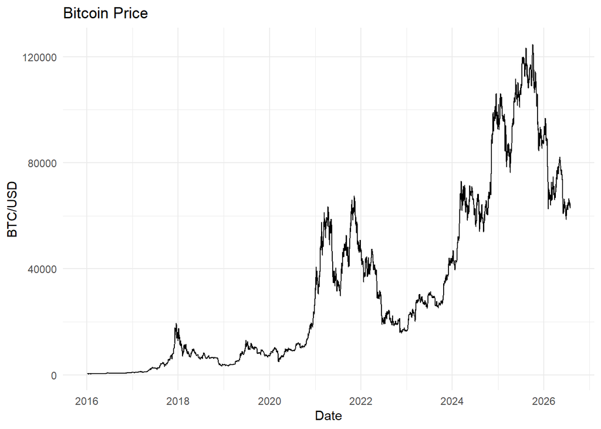

```r
ggplot(raw_combined, aes(x = Date, y = BTC)) +
  geom_line() +
  labs(
    title = "Bitcoin Price",
    x = "Date",
    y = "BTC/USD"
  ) +
  theme_minimal()
```

# 4 Log Return Plot

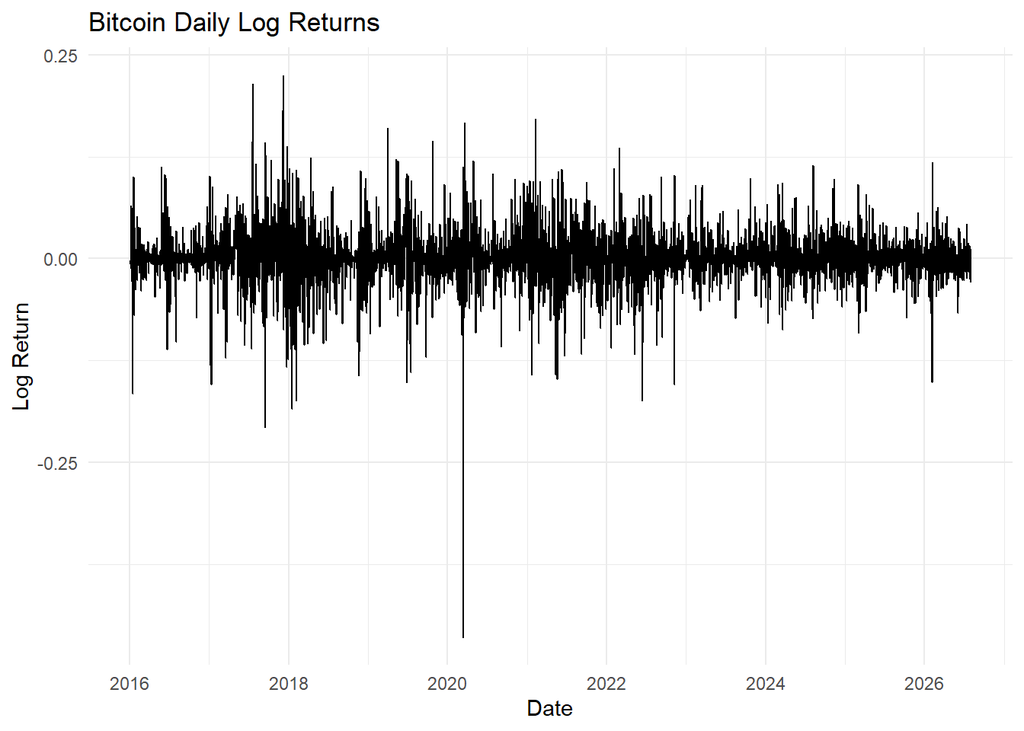

```r
ggplot(full_log, aes(x = Date, y = log_return)) +
  geom_line() +
  labs(
    title = "Bitcoin Daily Log Returns",
    x = "Date",
    y = "Log Return"
  ) +
  theme_minimal()
```

# 5 Descriptive Statistics

“Bal” indicates my data split using the same number od days post/pre ETF introduction. “Full” assumes all the data history from 2016.

```r
summary_data <- bind_rows(
  full_log |>
    select(Date, log_return) |>
    mutate(Period = "Full"),

  full_pre |>
    select(Date, log_return) |>
    mutate(Period = "Full_PreETF"),

  full_post |>
    select(Date, log_return) |>
    mutate(Period = "Full_PostETF"),

  balanced_pre |>
    select(Date, log_return) |>
    mutate(Period = "Bal_PreETF"),

  balanced_post |>
    select(Date, log_return) |>
    mutate(Period = "Bal_PostETF")
)

summary_table <- summary_data |>
  group_by(Period) |>
  summarise(
    N = sum(!is.na(log_return)),
    Mean = mean(log_return, na.rm = TRUE),
    Median = median(log_return, na.rm = TRUE),
    SD = sd(log_return, na.rm = TRUE),
    Min = min(log_return, na.rm = TRUE),
    Q05 = quantile(log_return, 0.05, na.rm = TRUE),
    Q25 = quantile(log_return, 0.25, na.rm = TRUE),
    Q75 = quantile(log_return, 0.75, na.rm = TRUE),
    Q95 = quantile(log_return, 0.95, na.rm = TRUE),
    Max = max(log_return, na.rm = TRUE),
    Skewness = skewness(log_return, na.rm = TRUE),
    Kurtosis = kurtosis(log_return, na.rm = TRUE)
  )

knitr::kable(
  summary_table,
  digits = 4,
  caption = "Descriptive Statistics of Bitcoin Log Returns"
)
```

Descriptive Statistics of Bitcoin Log Returns

| Period | N | Mean | Median | SD | Min | Q05 | Q25 | Q75 | Q95 | Max | Skewness | Kurtosis |
| --- | --- | --- | --- | --- | --- | --- | --- | --- | --- | --- | --- | --- |
| Bal_PostETF | 933 | 0.0003 | 0.0002 | 0.0249 | -0.1523 | -0.0382 | -0.0128 | 0.0126 | 0.0410 | 0.1180 | 0.0829 | 6.5481 |
| Bal_PreETF | 933 | 0.0004 | -0.0003 | 0.0301 | -0.1741 | -0.0472 | -0.0127 | 0.0148 | 0.0480 | 0.1358 | -0.3522 | 6.9096 |
| Full | 3861 | 0.0013 | 0.0011 | 0.0349 | -0.4647 | -0.0532 | -0.0127 | 0.0154 | 0.0535 | 0.2251 | -0.6609 | 15.3719 |
| Full_PostETF | 933 | 0.0003 | 0.0002 | 0.0249 | -0.1523 | -0.0382 | -0.0128 | 0.0126 | 0.0410 | 0.1180 | 0.0829 | 6.5481 |
| Full_PreETF | 2928 | 0.0016 | 0.0015 | 0.0375 | -0.4647 | -0.0593 | -0.0127 | 0.0170 | 0.0592 | 0.2251 | -0.7232 | 14.7967 |

# 6 Graphs

## 6.1 Histogram

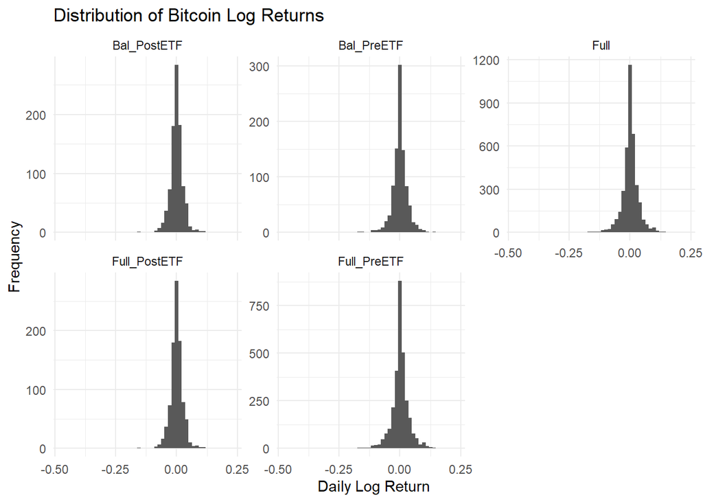

```r
ggplot(summary_data, aes(x = log_return)) +
  geom_histogram(bins = 50) +
  facet_wrap(~ Period, scales = "free_y") +
  labs(
    title = "Distribution of Bitcoin Log Returns",
    x = "Daily Log Return",
    y = "Frequency"
  ) +
  theme_minimal()
```

## 6.2 Density

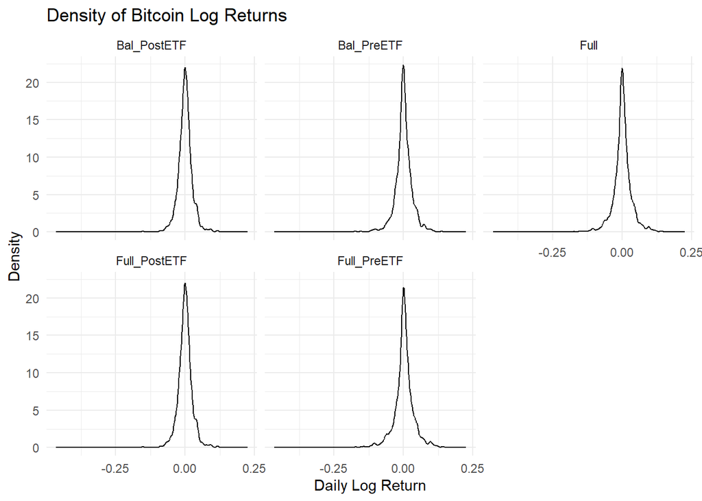

```r
ggplot(summary_data, aes(x = log_return)) +
  geom_density() +
  facet_wrap(~ Period) +
  labs(
    title = "Density of Bitcoin Log Returns",
    x = "Daily Log Return",
    y = "Density"
  ) +
  theme_minimal()
```

## 6.3 Pre/Post Histogram

**Using the balanced data**

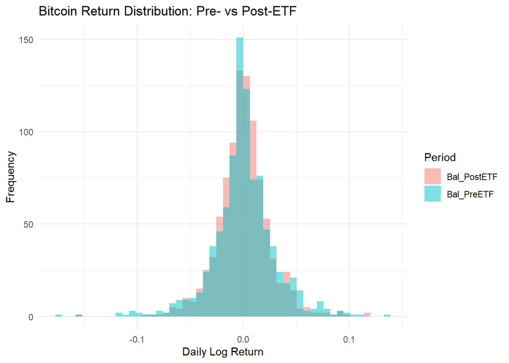

```r
summary_data |>
  filter(Period %in% c("Bal_PreETF", "Bal_PostETF")) |>
  ggplot(aes(
    x = log_return,
    fill = Period
  )) +
  geom_histogram(
    bins = 50,
    alpha = 0.5,
    position = "identity"
  ) +
  labs(
    title = "Bitcoin Return Distribution: Pre- vs Post-ETF",
    x = "Daily Log Return",
    y = "Frequency",
    fill = "Period"
  ) +
  theme_minimal()
```

## 6.4 QQ Plot

**Using Balanced data**

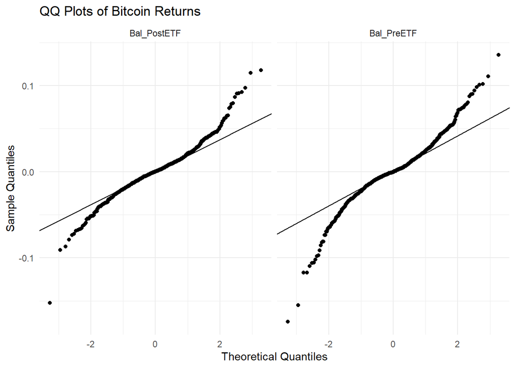

```r
summary_data |>
  filter(Period %in% c("Bal_PreETF", "Bal_PostETF")) |>
  ggplot(aes(sample = log_return)) +
  stat_qq() +
  stat_qq_line() +
  facet_wrap(~ Period) +
  labs(
    title = "QQ Plots of Bitcoin Returns",
    x = "Theoretical Quantiles",
    y = "Sample Quantiles"
  ) +
  theme_minimal()
```

## 6.5 Annualized 30d Realized Vol

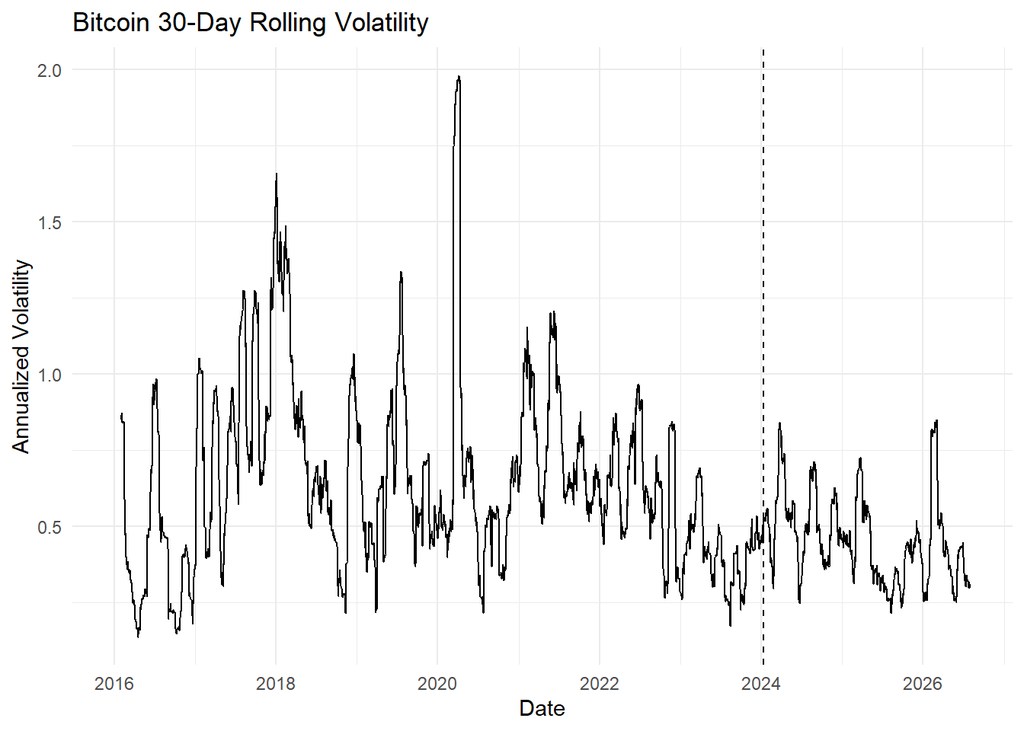

```r
full_log <- full_log |>
  mutate(
    vol_30d = rollapply(
      log_return,
      width = 30,
      FUN = sd,
      fill = NA,
      align = "right",
      na.rm = TRUE
    ),
    vol_30d_annualized = vol_30d * sqrt(365)
  )

ggplot(full_log, aes(x = Date, y = vol_30d_annualized)) +
  geom_line() +
  geom_vline(
    xintercept = as.Date("2024-01-11"),
    linetype = "dashed"
  ) +
  labs(
    title = "Bitcoin 30-Day Rolling Volatility",
    x = "Date",
    y = "Annualized Volatility"
  ) +
  theme_minimal()
```

# 7 Distribution Tests

## 7.1 Brown–Forsythe test

### 7.1.1 BF test on balanced data

The Brown–Forsythe test checks whether different groups have equal variances. It uses the median instead of the mean to reduce sensitivity to outliers. The null hypothesis is that the variances are equal across both periods.

```r
bf_data <- summary_data |>
  filter(Period %in% c("Bal_PreETF", "Bal_PostETF")) |>
  filter(!is.na(log_return))

leveneTest(
  log_return ~ Period,
  data = bf_data,
  center = median
)
```

```
Levene's Test for Homogeneity of Variance (center = median)
        Df F value   Pr(>F)
group    1  9.4591 0.002132 **
      1864
---
Signif. codes:  0 '***' 0.001 '**' 0.01 '*' 0.05 '.' 0.1 ' ' 1
```

### 7.1.2 BF test on data post 2022

The below code uses the 425-observation GARCH pre/post samples defined later in the analysis. This is different from my balanced data as I determined to instead rely on post FTX collapse data (post Nov 2022). I made the decision to focus on post FTX due to results on the structural break analysis.

```r
bf_425 <- bind_rows(
  garch_pre |> mutate(Period = "Pre_ETF"),
  garch_post |> mutate(Period = "Post_ETF")
)

car::leveneTest(
  log_return ~ Period,
  data = bf_425,
  center = median
)
```

```
Levene's Test for Homogeneity of Variance (center = median)
       Df F value    Pr(>F)
group   1  16.662 4.889e-05 ***
      848
---
Signif. codes:  0 '***' 0.001 '**' 0.01 '*' 0.05 '.' 0.1 ' ' 1
```

## 7.2 Welch test

Checking mean equality.

```r
welch_test <- t.test(
  log_return ~ Period,
  data = bf_data,
  var.equal = FALSE
)

welch_test
```

```
    Welch Two Sample t-test

data:  log_return by Period
t = -0.074282, df = 1801.9, p-value = 0.9408
alternative hypothesis: true difference in means between group Bal_PostETF and group Bal_PreETF is not equal to 0
95 percent confidence interval:
 -0.002603379  0.002413374
sample estimates:
mean in group Bal_PostETF  mean in group Bal_PreETF
             0.0003193757              0.0004143786
```

## 7.3 KS test

Used to determine if two independent samples come from the same underlying continuous distribution

```r
pre_returns <- bf_data |>
  filter(Period == "Bal_PreETF") |>
  pull(log_return)

post_returns <- bf_data |>
  filter(Period == "Bal_PostETF") |>
  pull(log_return)

ks_test <- ks.test(
  pre_returns,
  post_returns
)

ks_test
```

```
    Asymptotic two-sample Kolmogorov-Smirnov test

data:  pre_returns and post_returns
D = 0.043944, p-value = 0.3286
alternative hypothesis: two-sided
```

# 8 Diagnostic tests

## 8.1 ADF Test

### 8.1.1 ADF on full history

Test on the log price series (using the full data history) :

```r
adf.test(
  full_log$log_BTC,
  alternative = "stationary"
)
```

```
    Augmented Dickey-Fuller Test

data:  full_log$log_BTC
Dickey-Fuller = -2.0579, Lag order = 15, p-value = 0.5538
alternative hypothesis: stationary
```

### 8.1.2 ADF on Balanced history

```r
adf.test(
  garch_data_post2022$log_BTC,
  alternative = "stationary"
)
```

```
    Augmented Dickey-Fuller Test

data:  garch_data_post2022$log_BTC
Dickey-Fuller = -0.80391, Lag order = 11, p-value = 0.9613
alternative hypothesis: stationary
```

```r
adf.test(
  na.omit(garch_data_post2022$log_return),
  alternative = "stationary"
)
```

```
    Augmented Dickey-Fuller Test

data:  na.omit(garch_data_post2022$log_return)
Dickey-Fuller = -10.862, Lag order = 11, p-value = 0.01
alternative hypothesis: stationary
```

### 8.1.4 ADF on Log returns - balanced history

```r
adf.test(
  na.omit(garch_data_post2022$log_return),
  alternative = "stationary"
)
```

```
    Augmented Dickey-Fuller Test

data:  na.omit(garch_data_post2022$log_return)
Dickey-Fuller = -10.862, Lag order = 11, p-value = 0.01
alternative hypothesis: stationary
```

## 8.2 ACF /PACF Test

### 8.2.1 ACF on Full History

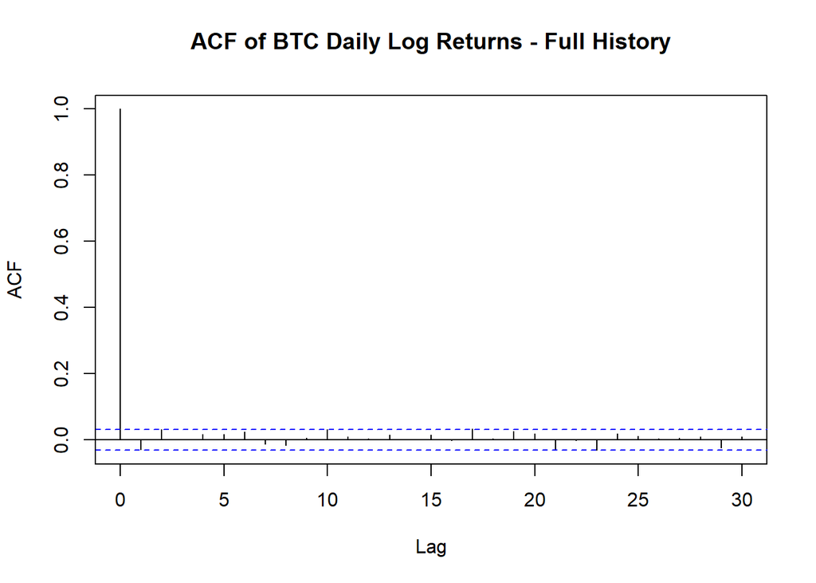

```r
acf(
  na.omit(full_log$log_return),
  lag.max = 30,
  main = "ACF of BTC Daily Log Returns - Full History"
)
```

### 8.2.2 ACF on Balanced History

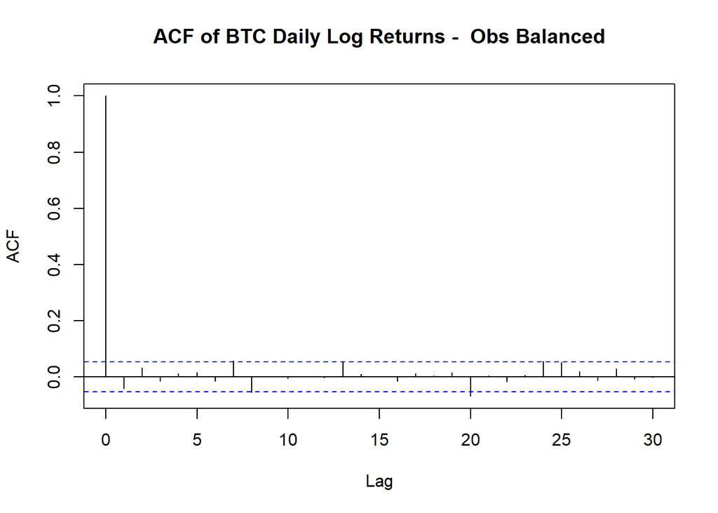

```r
acf(
  na.omit(garch_data_post2022$log_return),
  lag.max = 30,
  main = "ACF of BTC Daily Log Returns -  Obs Balanced"
)
```

## 8.3 ACF Squared Returns

### 8.3.1 ACF SR on Full History

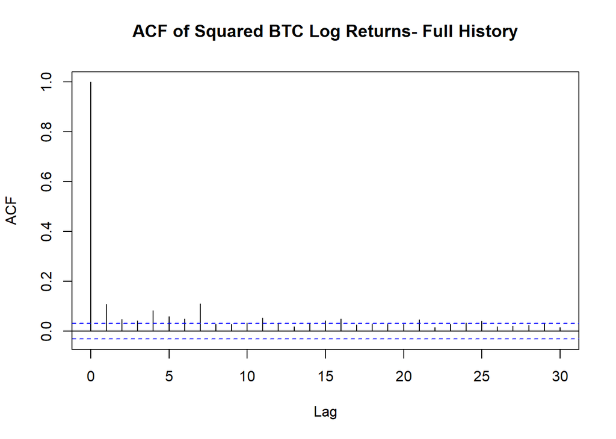

```r
acf(
  na.omit(full_log$log_return^2),
  lag.max = 30,
  main = "ACF of Squared BTC Log Returns- Full History"
)
```

### 8.3.2 ACF SR on Balanced History

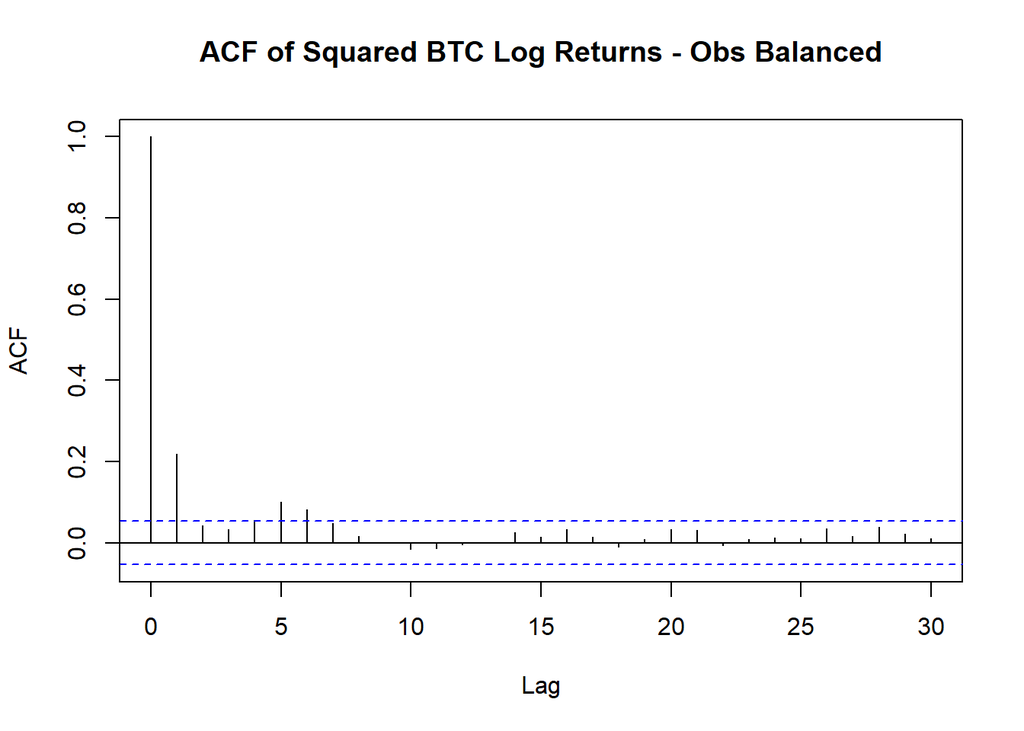

```r
acf(
  na.omit(garch_data_post2022$log_return^2),
  lag.max = 30,
  main = "ACF of Squared BTC Log Returns - Obs Balanced"
)
```

## 8.4 Ljung Box Test

### 8.4.1 LB Returns - Full History

Returns - Full Data :

```r
Box.test(
  na.omit(full_log$log_return),
  lag = 20,
  type = "Ljung-Box"
)
```

```
    Box-Ljung test

data:  na.omit(full_log$log_return)
X-squared = 26.229, df = 20, p-value = 0.1584
```

### 8.4.2 LB Returns - Balanced History

Returns - Balanced Data :

```r
Box.test(
  na.omit(garch_data_post2022$log_return),
  lag = 20,
  type = "Ljung-Box"
)
```

```
    Box-Ljung test

data:  na.omit(garch_data_post2022$log_return)
X-squared = 24.827, df = 20, p-value = 0.2081
```

### 8.4.3 LB Sq Returns - Full History

Squared returns - Full Data :

```r
Box.test(
  na.omit(full_log$log_return)^2,
  lag = 20,
  type = "Ljung-Box"
)
```

```
    Box-Ljung test

data:  na.omit(full_log$log_return)^2
X-squared = 215.52, df = 20, p-value < 2.2e-16
```

### 8.4.4 LB Sq Returns - Balanced History

Squared returns - Balanced Data :

```r
Box.test(
  na.omit(garch_data_post2022$log_return)^2,
  lag = 20,
  type = "Ljung-Box"
)
```

```
    Box-Ljung test

data:  na.omit(garch_data_post2022$log_return)^2
X-squared = 105.76, df = 20, p-value = 1.158e-13
```

## 8.5 Arch LM test

### 8.5.1 ARCH LM - Full History

- Full Data

```r
for (L in c(5, 10, 12, 20)) {

  print(
    FinTS::ArchTest(
      na.omit(full_log$log_return),
      lags = L,
      demean = TRUE
    )
  )
}
```

```
    ARCH LM-test; Null hypothesis: no ARCH effects

data:  na.omit(full_log$log_return)
Chi-squared = 81.965, df = 5, p-value = 3.255e-16


    ARCH LM-test; Null hypothesis: no ARCH effects

data:  na.omit(full_log$log_return)
Chi-squared = 120.36, df = 10, p-value < 2.2e-16


    ARCH LM-test; Null hypothesis: no ARCH effects

data:  na.omit(full_log$log_return)
Chi-squared = 125.66, df = 12, p-value < 2.2e-16


    ARCH LM-test; Null hypothesis: no ARCH effects

data:  na.omit(full_log$log_return)
Chi-squared = 133.42, df = 20, p-value < 2.2e-16
```

### 8.5.2 ARCH LM - Balanced History

- Balanced Data

```r
for (L in c(5, 10, 12, 20)) {

  print(
    FinTS::ArchTest(
      na.omit(garch_data_post2022$log_return),
      lags = L,
      demean = TRUE
    )
  )
}
```

```
    ARCH LM-test; Null hypothesis: no ARCH effects

data:  na.omit(garch_data_post2022$log_return)
Chi-squared = 79.066, df = 5, p-value = 1.316e-15


    ARCH LM-test; Null hypothesis: no ARCH effects

data:  na.omit(garch_data_post2022$log_return)
Chi-squared = 82.91, df = 10, p-value = 1.347e-13


    ARCH LM-test; Null hypothesis: no ARCH effects

data:  na.omit(garch_data_post2022$log_return)
Chi-squared = 83.199, df = 12, p-value = 1.009e-12


    ARCH LM-test; Null hypothesis: no ARCH effects

data:  na.omit(garch_data_post2022$log_return)
Chi-squared = 86.766, df = 20, p-value = 2.71e-10
```

# 9 Structural break analysis

## 9.1 Bai Perron (unknown break test date)

These tests are reviewing/detecting shifts in unconditional mean and returns across regimes.

The algorithm searches through possible combinations of dates and finds the segmentation that best fits the data. It works by minimizing the sum of squared residuals across all possible partitions of the sample into m regimes, using dynamic programming for efficiency, and provides test statistics to determine both the number of breaks and their locations.

### 9.1.1 BP - Mean

Below model is running is running on the full unrestricted historical data

```r
bp_data <- full_log |>
  filter(!is.na(log_return)) |>
  arrange(Date) |>
  mutate(return_sq = log_return^2)
```

Bai–Perron on the mean (Shows no unrestricted break in the mean):

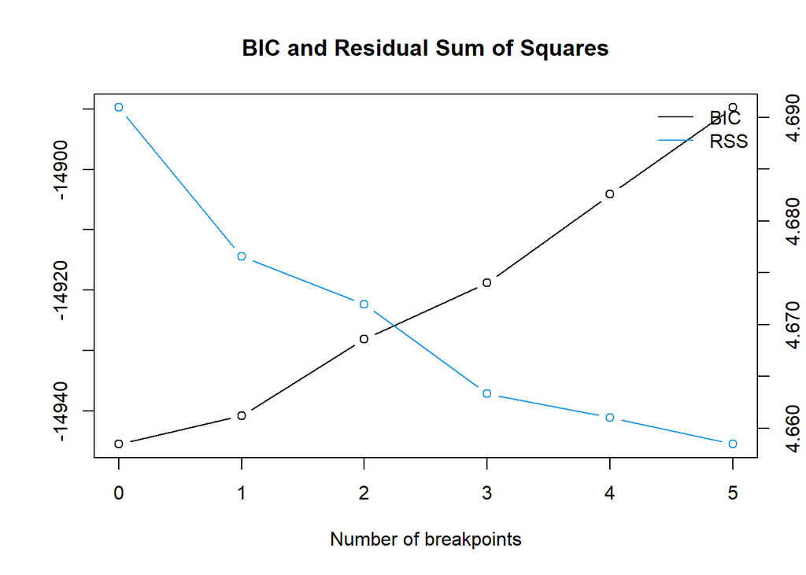

```r
bp_mean <- breakpoints(
  log_return ~ 1,
  data = bp_data,
  h = 0.15
)

plot(bp_mean)
```

```r
#bp_data$Date[breakpoints(bp_mean)$breakpoints]
```

### 9.1.2 BP - Squared Returns

Bai–Perron on squared returns (1 break) :

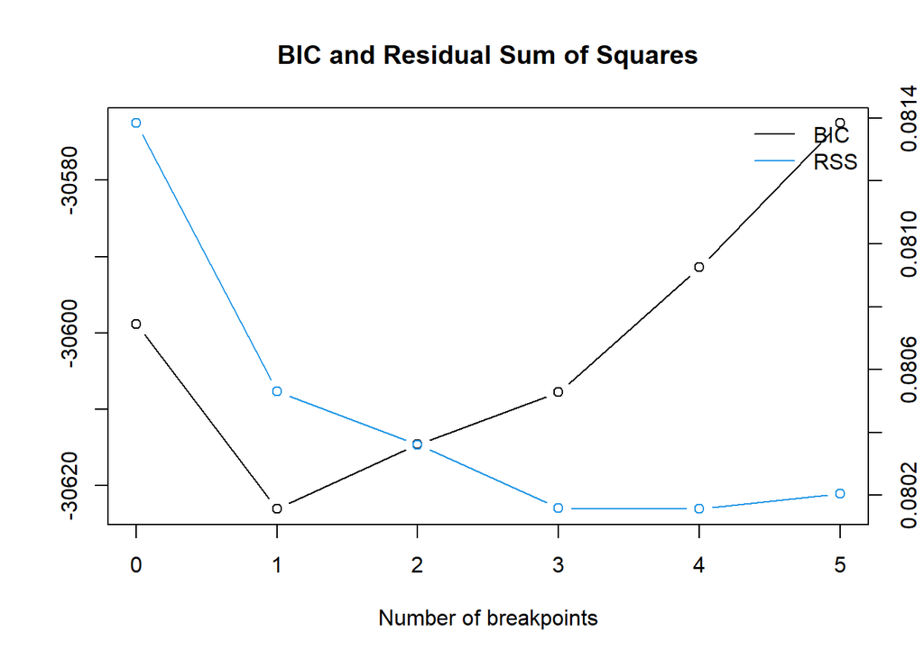

```r
bp_vol <- breakpoints(
  return_sq ~ 1,
  data = bp_data,
  h = 0.15
)

#summary(bp_mean)
#summary(bp_vol)

plot(bp_vol)
```

```r
#bp_data$Date[breakpoints(bp_mean)$breakpoints]
#bp_data$Date[breakpoints(bp_vol)$breakpoints]
```

Date of the break:

```r
bp_data$Date[breakpoints(bp_vol)$breakpoints]
```

```
[1] "2022-06-19"
```

### 9.1.3 BP - Post 2022/FTX

Running on an amended timeframe to avoid the major FTX impact in 2022. Bai–Perron on squared returns (0 breaks) :

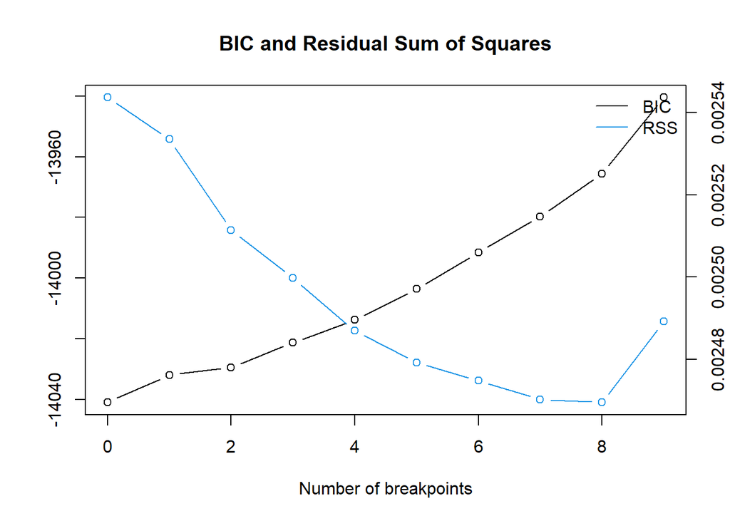

```r
bp_data_post2022 <- full_log |>
  filter(!is.na(log_return)) |>
  arrange(Date) |>
  mutate(return_sq = log_return^2) |>
  filter(Date >= as.Date("2022-11-12"))

bp_vol_postftx <- breakpoints(
  return_sq ~ 1,
  data = bp_data_post2022,
  h = 0.10
)

plot(bp_vol_postftx)
```

```r
#summary(bp_vol_postftx)
#bp_data_post2022$Date[breakpoints(bp_vol_postftx)$breakpoints]
```

## 9.2 Chow Test (known date)

Chow test asks directly whether 11 January 2024, the ETF approval date, is itself a structural break.

```r
etf_date <- as.Date("2024-01-11")
etf_obs <- which(bp_data_post2022$Date == etf_date)
```

### 9.2.1 Chow Test - Returns

Chow test on returns:

```r
chow_mean <- sctest(
  log_return ~ 1,
  type = "Chow",
  point = etf_obs,
  data = bp_data_post2022
)
print(chow_mean)
```

```
    Chow test

data:  log_return ~ 1
F = 2.0586, p-value = 0.1516
```

### 9.2.2 Chow Test - Squared Returns

Chow test on squared returns:

```r
chow_var <- sctest(
  return_sq ~ 1,
  type = "Chow",
  point = etf_obs,
  data = bp_data_post2022
)
print(chow_var)
```

```
    Chow test

data:  return_sq ~ 1
F = 2.31, p-value = 0.1288
```

## 9.3 CUMSUM on variance

CUSUM tests whether the model parameters remain stable over time by tracking the cumulative sum of residuals and checking whether it stays within critical bounds

CUSUM on variance:

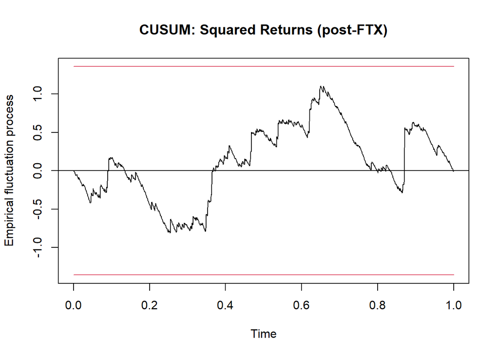

```r
cusum_var <- efp(
  return_sq ~ 1,
  type = "OLS-CUSUM",
  data = bp_data_post2022
)

plot(cusum_var, main = "CUSUM: Squared Returns (post-FTX)")
```

# 10 GARCH Models

## 10.1 GARCH

Added Observations on the models after the each result

### 10.1.1 GARCH(1,1) - Post 2022

```r
garch_data_post2022 <- full_log |>
  filter(
    Date > as.Date("2022-11-11"),
    !is.na(log_return)
  ) |>
  arrange(Date) |>
  mutate(
    ETF_dummy = if_else(
      Date >= as.Date("2024-01-11"),
      1,
      0
    )
  )

garch_spec <- ugarchspec(
  variance.model = list(
    model = "sGARCH",
    garchOrder = c(1, 1)
  ),
  mean.model = list(
    armaOrder = c(0, 0),
    include.mean = TRUE
  ),
  distribution.model = "std"
)

garch_fit <- ugarchfit(
  spec = garch_spec,
  data = garch_data_post2022$log_return,
  solver = "hybrid"
)
```

Summary of the fitted model:

```r
garch_fit
```

```
*---------------------------------*
*          GARCH Model Fit        *
*---------------------------------*

Conditional Variance Dynamics
-----------------------------------
GARCH Model : sGARCH(1,1)
Mean Model  : ARFIMA(0,0,0)
Distribution    : std

Optimal Parameters
------------------------------------
        Estimate  Std. Error  t value Pr(>|t|)
mu      0.000481    0.000502  0.95691 0.338612
omega   0.000017    0.000020  0.83081 0.406079
alpha1  0.061672    0.040037  1.54036 0.123471
beta1   0.923953    0.027332 33.80441 0.000000
shape   3.331366    0.675989  4.92814 0.000001

Robust Standard Errors:
        Estimate  Std. Error  t value Pr(>|t|)
mu      0.000481    0.000490  0.98128  0.32645
omega   0.000017    0.000091  0.18768  0.85112
alpha1  0.061672    0.176052  0.35031  0.72611
beta1   0.923953    0.097423  9.48396  0.00000
shape   3.331366    2.664007  1.25051  0.21111

LogLikelihood : 3252.92

Information Criteria
------------------------------------

Akaike       -4.7834
Bayes        -4.7642
Shibata      -4.7834
Hannan-Quinn -4.7762

Weighted Ljung-Box Test on Standardized Residuals
------------------------------------
                        statistic p-value
```

[output cut: 39 more lines]

```
Negative Sign Bias   3.259 0.001145 ***
Positive Sign Bias   1.069 0.285302
Joint Effect        11.772 0.008207 ***


Adjusted Pearson Goodness-of-Fit Test:
------------------------------------
  group statistic p-value(g-1)
1    20     31.34      0.03706
2    30     40.60      0.07458
3    40     47.77      0.15827
4    50     61.73      0.10467


Elapsed time : 0.1090288
```

Persistance:

```r
#Persistance
persistence(garch_fit)
```

```
[1] 0.985625
```

Observations:

- Very high volatility persistence: α+β≈0.986, so volatility shocks decay slowly
- Mean return is not significant, while β is strongly significant
- Residual autocorrelation is largely removed, suggesting the mean specification is adequate
- Squared residuals still show dependence, indicating some volatility dynamics remain unexplained
- Nyblom test indicates parameter instability over the sample
- Sign-bias test indicates asymmetry, particularly for negative shocks

### 10.1.2 ETF Dummy

```r
etf_xreg <- matrix(
  garch_data_post2022$ETF_dummy,
  ncol = 1
)

garch_etf_spec <- ugarchspec(
  variance.model = list(
    model = "sGARCH",
    garchOrder = c(1, 1),
    external.regressors = etf_xreg
  ),
  mean.model = list(
    armaOrder = c(0, 0),
    include.mean = TRUE
  ),
  distribution.model = "std"
)

garch_etf_fit <- ugarchfit(
  spec = garch_etf_spec,
  data = garch_data_post2022$log_return,
  solver = "hybrid"
)

garch_etf_fit
```

```
*---------------------------------*
*          GARCH Model Fit        *
*---------------------------------*

Conditional Variance Dynamics
-----------------------------------
GARCH Model : sGARCH(1,1)
Mean Model  : ARFIMA(0,0,0)
Distribution    : std

Optimal Parameters
------------------------------------
        Estimate  Std. Error  t value Pr(>|t|)
mu      0.000446    0.000494  0.90246  0.36681
omega   0.000012    0.000006  2.13002  0.03317
alpha1  0.062240    0.011041  5.63729  0.00000
beta1   0.920960    0.021430 42.97503  0.00000
vxreg1  0.000011    0.000008  1.40293  0.16064
shape   3.261361    0.235368 13.85646  0.00000

Robust Standard Errors:
        Estimate  Std. Error  t value Pr(>|t|)
mu      0.000446    0.000436  1.02151 0.307014
omega   0.000012    0.000011  1.08599 0.277484
alpha1  0.062240    0.021109  2.94852 0.003193
beta1   0.920960    0.035361 26.04430 0.000000
vxreg1  0.000011    0.000012  0.96466 0.334717
shape   3.261361    0.416201  7.83603 0.000000

LogLikelihood : 3255.22

Information Criteria
------------------------------------

Akaike       -4.7853
Bayes        -4.7623
Shibata      -4.7853
Hannan-Quinn -4.7767

Weighted Ljung-Box Test on Standardized Residuals
```

[output cut: 42 more lines]

```
Negative Sign Bias  3.0049 0.002705 ***
Positive Sign Bias  0.9996 0.317706
Joint Effect       10.0579 0.018081  **


Adjusted Pearson Goodness-of-Fit Test:
------------------------------------
  group statistic p-value(g-1)
1    20     25.68      0.13930
2    30     41.04      0.06828
3    40     44.83      0.24063
4    50     66.59      0.04786


Elapsed time : 0.1655381
```

Observations:

- ETF variance dummy is positive but not statistically significant
- Model fit changes very little versus the baseline GARCH

### 10.1.3 Pre/Post Garch

```r
garch_pre <- garch_data_post2022 |>
  filter(ETF_dummy == 0)

n_regime <- nrow(garch_pre)

garch_post <- garch_data_post2022 |>
  filter(ETF_dummy == 1) |>
  slice_head(n = n_regime)


garch_pre_fit <- ugarchfit(
  spec = garch_spec,
  data = garch_pre$log_return,
  solver = "hybrid"
)

garch_post_fit <- ugarchfit(
  spec = garch_spec,
  data = garch_post$log_return,
  solver = "hybrid"
)
```

Pre ETF results:

```r
garch_pre_fit
```

```
*---------------------------------*
*          GARCH Model Fit        *
*---------------------------------*

Conditional Variance Dynamics
-----------------------------------
GARCH Model : sGARCH(1,1)
Mean Model  : ARFIMA(0,0,0)
Distribution    : std

Optimal Parameters
------------------------------------
        Estimate  Std. Error  t value Pr(>|t|)
mu      0.000491    0.000743  0.66098 0.508625
omega   0.000011    0.000005  2.22086 0.026361
alpha1  0.054038    0.013664  3.95465 0.000077
beta1   0.944962    0.018287 51.67321 0.000000
shape   2.699429    0.249355 10.82563 0.000000

Robust Standard Errors:
        Estimate  Std. Error  t value Pr(>|t|)
mu      0.000491    0.000671  0.73196 0.464194
omega   0.000011    0.000006  1.95629 0.050431
alpha1  0.054038    0.012314  4.38844 0.000011
beta1   0.944962    0.020870 45.27772 0.000000
shape   2.699429    0.231060 11.68281 0.000000

LogLikelihood : 1060.622

Information Criteria
------------------------------------

Akaike       -4.9676
Bayes        -4.9200
Shibata      -4.9679
Hannan-Quinn -4.9488

Weighted Ljung-Box Test on Standardized Residuals
------------------------------------
                        statistic p-value
```

[output cut: 39 more lines]

```
Negative Sign Bias  1.6216 0.10563
Positive Sign Bias  0.7585 0.44857
Joint Effect        9.5286 0.02303  **


Adjusted Pearson Goodness-of-Fit Test:
------------------------------------
  group statistic p-value(g-1)
1    20     34.34     0.016746
2    30     52.95     0.004260
3    40     65.64     0.004817
4    50     72.29     0.016858


Elapsed time : 0.050143
```

Post ETF results:

```r
garch_post_fit
```

```
*---------------------------------*
*          GARCH Model Fit        *
*---------------------------------*

Conditional Variance Dynamics
-----------------------------------
GARCH Model : sGARCH(1,1)
Mean Model  : ARFIMA(0,0,0)
Distribution    : std

Optimal Parameters
------------------------------------
        Estimate  Std. Error  t value Pr(>|t|)
mu      0.000831    0.001145  0.72547 0.468166
omega   0.000062    0.000059  1.05191 0.292843
alpha1  0.058974    0.038441  1.53412 0.125000
beta1   0.871870    0.096421  9.04230 0.000000
shape   4.163291    1.034527  4.02434 0.000057

Robust Standard Errors:
        Estimate  Std. Error  t value Pr(>|t|)
mu      0.000831    0.001056  0.78668  0.43147
omega   0.000062    0.000055  1.12538  0.26043
alpha1  0.058974    0.037078  1.59051  0.11172
beta1   0.871870    0.086852 10.03856  0.00000
shape   4.163291    0.782729  5.31895  0.00000

LogLikelihood : 942.0457

Information Criteria
------------------------------------

Akaike       -4.4096
Bayes        -4.3620
Shibata      -4.4099
Hannan-Quinn -4.3908

Weighted Ljung-Box Test on Standardized Residuals
------------------------------------
                        statistic p-value
```

[output cut: 39 more lines]

```
Negative Sign Bias  0.4596 0.6460
Positive Sign Bias  1.2954 0.1959
Joint Effect        2.0200 0.5683


Adjusted Pearson Goodness-of-Fit Test:
------------------------------------
  group statistic p-value(g-1)
1    20     14.58       0.7491
2    30     24.86       0.6856
3    40     32.51       0.7593
4    50     36.06       0.9155


Elapsed time : 0.08626914
```

Observations:

- Volatility persistence falls substantially pre vs post
- Mean returns are insignificant in both periods.
- Pre-ETF: strong persistence and significant ARCH respons with Nyblom and sign-bias tests indicate instability/asymmetry.
- Post-ETF: residual diagnostics, stability tests and sign-bias tests are substantially cleaner, suggesting the GARCH specification fits the post period better.

## 10.2 GJR-GARCH

### 10.2.1 GJR-GARCH (1,1)

```r
gjr_spec <- ugarchspec(
  variance.model = list(
    model = "gjrGARCH",
    garchOrder = c(1, 1)
  ),
  mean.model = list(
    armaOrder = c(0, 0),
    include.mean = TRUE
  ),
  distribution.model = "std"
)

gjr_fit <- ugarchfit(
  spec = gjr_spec,
  data = garch_data_post2022$log_return,
  solver = "hybrid"
)

gjr_fit
```

```
*---------------------------------*
*          GARCH Model Fit        *
*---------------------------------*

Conditional Variance Dynamics
-----------------------------------
GARCH Model : gjrGARCH(1,1)
Mean Model  : ARFIMA(0,0,0)
Distribution    : std

Optimal Parameters
------------------------------------
        Estimate  Std. Error  t value Pr(>|t|)
mu      0.000367    0.000503  0.73025 0.465236
omega   0.000024    0.000015  1.58854 0.112164
alpha1  0.042424    0.018740  2.26379 0.023587
beta1   0.902575    0.038445 23.47675 0.000000
gamma1  0.069054    0.038506  1.79336 0.072916
shape   3.377869    0.369237  9.14824 0.000000

Robust Standard Errors:
        Estimate  Std. Error  t value Pr(>|t|)
mu      0.000367    0.000452  0.81165 0.416990
omega   0.000024    0.000022  1.09696 0.272658
alpha1  0.042424    0.020522  2.06720 0.038716
beta1   0.902575    0.054308 16.61962 0.000000
gamma1  0.069054    0.052917  1.30496 0.191906
shape   3.377869    0.318247 10.61398 0.000000

LogLikelihood : 3255.689

Information Criteria
------------------------------------

Akaike       -4.7860
Bayes        -4.7630
Shibata      -4.7860
Hannan-Quinn -4.7774

Weighted Ljung-Box Test on Standardized Residuals
```

[output cut: 42 more lines]

```
Negative Sign Bias   2.070 0.03863  **
Positive Sign Bias   1.519 0.12910
Joint Effect         7.062 0.06995   *


Adjusted Pearson Goodness-of-Fit Test:
------------------------------------
  group statistic p-value(g-1)
1    20     24.89      0.16431
2    30     42.72      0.04830
3    40     51.37      0.08875
4    50     64.97      0.06284


Elapsed time : 0.2768362
```

Observations:

- Volatility Is Persistent
- The ARCH term is significant, while the asymmetric term γ is positive but not significant with robust standard errors
- Compared with the symmetric GARCH, the GJR specification improves parameter stability -nyblom
- Squared residuals still show some remaining dependence
- GJR-GARCH provides a slightly better fit but the evidence for a strong leverage/asymmetry effect is limited.

### 10.2.2 ETF Dummy

```r
gjr_etf_spec <- ugarchspec(
  variance.model = list(
    model = "gjrGARCH",
    garchOrder = c(1, 1),
    external.regressors = etf_xreg
  ),
  mean.model = list(
    armaOrder = c(0, 0),
    include.mean = TRUE
  ),
  distribution.model = "std"
)

gjr_etf_fit <- ugarchfit(
  spec = gjr_etf_spec,
  data = garch_data_post2022$log_return,
  solver = "hybrid"
)

gjr_etf_fit
```

```
*---------------------------------*
*          GARCH Model Fit        *
*---------------------------------*

Conditional Variance Dynamics
-----------------------------------
GARCH Model : gjrGARCH(1,1)
Mean Model  : ARFIMA(0,0,0)
Distribution    : std

Optimal Parameters
------------------------------------
        Estimate  Std. Error  t value Pr(>|t|)
mu      0.000364    0.000500  0.72866 0.466209
omega   0.000020    0.000019  1.06648 0.286208
alpha1  0.048193    0.021194  2.27392 0.022971
beta1   0.897094    0.054310 16.51799 0.000000
gamma1  0.060874    0.042053  1.44755 0.147742
vxreg1  0.000011    0.000010  1.10122 0.270802
shape   3.320209    0.354332  9.37034 0.000000

Robust Standard Errors:
        Estimate  Std. Error  t value Pr(>|t|)
mu      0.000364    0.000458  0.79421  0.42707
omega   0.000020    0.000038  0.54654  0.58470
alpha1  0.048193    0.025681  1.87662  0.06057
beta1   0.897094    0.102736  8.73207  0.00000
gamma1  0.060874    0.067348  0.90387  0.36607
vxreg1  0.000011    0.000016  0.67743  0.49813
shape   3.320209    0.307785 10.78743  0.00000

LogLikelihood : 3256.939

Information Criteria
------------------------------------

Akaike       -4.7864
Bayes        -4.7595
Shibata      -4.7864
Hannan-Quinn -4.7763
```

[output cut: 45 more lines]

```
Negative Sign Bias  2.0525 0.04031  **
Positive Sign Bias  1.3059 0.19180
Joint Effect        6.4713 0.09080   *


Adjusted Pearson Goodness-of-Fit Test:
------------------------------------
  group statistic p-value(g-1)
1    20     26.86      0.10795
2    30     46.83      0.01937
3    40     51.84      0.08184
4    50     53.63      0.30116


Elapsed time : 0.2858078
```

Obesrevations:

- ETF variance dummy remains insignificant
- The asymmetry coefficient γ is also insignificant
- Volatility persistence remains high
- ETF dummy provides almost no improvement in fit

### 10.2.3 Pre/Post Garch

```r
gjr_spec <- ugarchspec(
  variance.model = list(
    model = "gjrGARCH",
    garchOrder = c(1, 1)
  ),
  mean.model = list(
    armaOrder = c(0, 0),
    include.mean = TRUE
  ),
  distribution.model = "std"
)

gjr_pre_fit <- ugarchfit(
  spec = gjr_spec,
  data = garch_pre$log_return,
  solver = "hybrid"
)

gjr_post_fit <- ugarchfit(
  spec = gjr_spec,
  data = garch_post$log_return,
  solver = "hybrid"
)

gjr_pre_fit
```

```
*---------------------------------*
*          GARCH Model Fit        *
*---------------------------------*

Conditional Variance Dynamics
-----------------------------------
GARCH Model : gjrGARCH(1,1)
Mean Model  : ARFIMA(0,0,0)
Distribution    : std

Optimal Parameters
------------------------------------
        Estimate  Std. Error   t value Pr(>|t|)
mu      0.000536    0.000663   0.80896  0.41854
omega   0.000005    0.000010   0.48902  0.62483
alpha1  0.064724    0.066123   0.97884  0.32766
beta1   0.972489    0.009230 105.35836  0.00000
gamma1 -0.085258    0.059675  -1.42871  0.15309
shape   2.639269    0.213729  12.34866  0.00000

Robust Standard Errors:
        Estimate  Std. Error  t value Pr(>|t|)
mu      0.000536    0.001278  0.41940 0.674923
omega   0.000005    0.000044  0.10909 0.913127
alpha1  0.064724    0.302858  0.21371 0.830772
beta1   0.972489    0.042037 23.13386 0.000000
gamma1 -0.085258    0.267340 -0.31891 0.749794
shape   2.639269    1.389543  1.89938 0.057515

LogLikelihood : 1062.358

Information Criteria
------------------------------------

Akaike       -4.9711
Bayes        -4.9139
Shibata      -4.9715
Hannan-Quinn -4.9485

Weighted Ljung-Box Test on Standardized Residuals
```

[output cut: 42 more lines]

```
Negative Sign Bias  1.9261 0.05477   *
Positive Sign Bias  0.5538 0.58001
Joint Effect        9.9994 0.01857  **


Adjusted Pearson Goodness-of-Fit Test:
------------------------------------
  group statistic p-value(g-1)
1    20     34.44     0.016320
2    30     42.08     0.055209
3    40     62.44     0.009984
4    50     72.29     0.016858


Elapsed time : 0.1678829
```

```r
gjr_post_fit
```

```
*---------------------------------*
*          GARCH Model Fit        *
*---------------------------------*

Conditional Variance Dynamics
-----------------------------------
GARCH Model : gjrGARCH(1,1)
Mean Model  : ARFIMA(0,0,0)
Distribution    : std

Optimal Parameters
------------------------------------
        Estimate  Std. Error  t value Pr(>|t|)
mu      0.000683    0.001145  0.59601  0.55117
omega   0.000080    0.000071  1.12299  0.26144
alpha1  0.037577    0.035123  1.06988  0.28467
beta1   0.839704    0.107667  7.79906  0.00000
gamma1  0.073519    0.071725  1.02502  0.30535
shape   4.186254    1.018722  4.10932  0.00004

Robust Standard Errors:
        Estimate  Std. Error  t value Pr(>|t|)
mu      0.000683    0.001098  0.62172  0.53413
omega   0.000080    0.000063  1.25964  0.20780
alpha1  0.037577    0.033297  1.12855  0.25909
beta1   0.839704    0.093113  9.01807  0.00000
gamma1  0.073519    0.079977  0.91926  0.35796
shape   4.186254    0.785739  5.32779  0.00000

LogLikelihood : 942.7852

Information Criteria
------------------------------------

Akaike       -4.4084
Bayes        -4.3512
Shibata      -4.4088
Hannan-Quinn -4.3858

Weighted Ljung-Box Test on Standardized Residuals
```

[output cut: 42 more lines]

```
Negative Sign Bias 0.02321 0.9815
Positive Sign Bias 1.59734 0.1109
Joint Effect       2.57014 0.4627


Adjusted Pearson Goodness-of-Fit Test:
------------------------------------
  group statistic p-value(g-1)
1    20     10.34       0.9440
2    30     20.34       0.8820
3    40     31.00       0.8158
4    50     35.59       0.9242


Elapsed time : 0.2204142
```

Observations:

- Estimated volatility persistence falls materially -> 0.995 pre-ETF vs. 0.914 post-ETF
- The asymmetry coefficient γ is insignificant in both periods
- Pre-ETF: GJR substantially improves parameter stability relative to the symmetric GARCH
- Post-ETF: No residual autocorrelation, no significant sign bias, stable parameters, and strong goodness-of-fit
- Post-ETF volatility process appears less persistent and more stable

### 10.2.4 LR Test

Pre and post have the same number of rows, so they are reunited for the LR test.

```r
garch_balanced <- bind_rows(
  garch_pre,
  garch_post
) |>
  arrange(Date)

nrow(garch_balanced)
```

```
[1] 850
```

```r
nrow(garch_pre) + nrow(garch_post)
```

```
[1] 850
```

```r
gjr_pooled_bal_fit <- ugarchfit(
  spec = gjr_spec,
  data = garch_balanced$log_return,
  solver = "hybrid"
)

ll_pooled <- likelihood(gjr_pooled_bal_fit)

ll_separate <-
  likelihood(gjr_pre_fit) +
  likelihood(gjr_post_fit)

LR <- 2 * (ll_separate - ll_pooled)

LR
```

```
[1] 17.16587
```

```r
p_LR <- pchisq(
  LR,
  df = 6,
  lower.tail = FALSE
)

p_LR
```

```
[1] 0.008692578
```

Observation:

- LR statistic = 17.17, with p = 0.0087.
- Null Hypothesis is rejected: the overall conditional-volatility process differs significantly across the two periods.

# 11 Markov-switching mean/variance model

The Markov-switching model is used as an alternative way to capture changes in Bitcoin volatility without imposing a fixed structural break date. I use a simple two-state specification in which only the conditional mean and variance are allowed to switch across regimes

Model Estimation:

```r
ms_base <- lm(
  log_return ~ 1,
  data = garch_data_post2022
)

set.seed(123)

ms_fit <- msmFit(
  ms_base,
  k = 2,
  p = 0,
  sw = c(TRUE, TRUE),
  control = list(
    parallel = FALSE
  )
)

summary(ms_fit)
```

```
Markov Switching Model

Call: msmFit(object = ms_base, k = 2, sw = c(TRUE, TRUE), p = 0, control = list(parallel = FALSE))

        AIC       BIC   logLik
  -6476.487 -6451.632 3240.243

Coefficients:

Regime 1
---------
               Estimate Std. Error t value Pr(>|t|)
(Intercept)(S)    2e-04      6e-04  0.3333   0.7389

Residual standard error: 0.01299698
Multiple R-squared:     0

Standardized Residuals:
          Min            Q1           Med            Q3           Max
-2.211342e-02 -7.275040e-03 -7.103482e-05  8.259654e-03  2.111594e-02

Regime 2
---------
               Estimate Std. Error t value Pr(>|t|)
(Intercept)(S)   0.0021     0.0017  1.2353   0.2167

Residual standard error: 0.03504716
Multiple R-squared:     0

Standardized Residuals:
          Min            Q1           Med            Q3           Max
-0.1544739215 -0.0062368695 -0.0007877227  0.0049822737  0.1158636679

Transition probabilities:
          Regime 1 Regime 2
Regime 1 0.7822245 0.342555
Regime 2 0.2177755 0.657445
```

Observations:

- Identifies a low-volatility and a high-volatility regime
- Differences are driven mainly by volatility rather than mean returns.

Regime occupancy (Using full post 2022 data) :

```r
high_state <- 2
smooth_prob <- ms_fit@Fit@smoProb[-1, , drop = FALSE]

ms_data <- garch_data_post2022 |>
  mutate(
    Prob_HighVol = smooth_prob[, 2]
  )

ms_summary <- ms_data |>
  mutate(
    Period = if_else(
      Date < as.Date("2024-01-11"),
      "Pre_ETF",
      "Post_ETF"
    )
  ) |>
  group_by(Period) |>
  summarise(
    N = n(),
    Avg_HighVol_Prob = mean(Prob_HighVol),
    HighVol_Share = mean(Prob_HighVol > 0.5)
  )

ms_summary
```

```
# A tibble: 2 × 4
  Period       N Avg_HighVol_Prob HighVol_Share
  <chr>    <int>            <dbl>         <dbl>
1 Post_ETF   933            0.410         0.314
2 Pre_ETF    425            0.343         0.233
```

Observations:

- The full post-FTX sample suggests greater high-volatility regime occupancy after ETF approval. However due to the unbalanced observation I rerun below to review using balanced pre ETF and Post ETF data.

Balanced dates:

```r
ms_balanced <- ms_data |>
  filter(Date %in% c(garch_pre$Date, garch_post$Date)) |>
  mutate(
    Period = if_else(
      Date < as.Date("2024-01-11"),
      "Pre_ETF",
      "Post_ETF"
    )
  )

ms_balanced_summary <- ms_balanced |>
  group_by(Period) |>
  summarise(
    N = n(),
    Avg_HighVol_Prob = mean(Prob_HighVol),
    HighVol_Share = mean(Prob_HighVol > 0.5)
  )

ms_balanced_summary
```

```
# A tibble: 2 × 4
  Period       N Avg_HighVol_Prob HighVol_Share
  <chr>    <int>            <dbl>         <dbl>
1 Post_ETF   425            0.483         0.407
2 Pre_ETF    425            0.343         0.233
```

Observations:

- In the balanced sample, high-volatility regime occupancy is higher post-ETF.